# Exercise 03

Author

Dipayan Akhuli (dipayan-akhuli)

Published

October 10, 2023

## Exploratory Data Analysis

Do an exploratory data analysis of a matrix of expression values. The data consists of expression values for samples that were treated with DMSO and TSA. The samples were measured using three technologies: bulk, IFC96, IFC800. See the two RDS files `counts.RDS` and `phenodata.RDS`.

The experiment has two experimental factors “Treatment” and “Technology”. Treatment has two levels, Technology has three levels. Samples that have the same combination of Treatment & Technology are replicates.

## Data Import

```r
x = readRDS("counts.RDS")
anno = readRDS("phenodata.RDS")
head(anno)
```

```
                      Treatment Technology
bulk.DMSO-Pre-96IFC        DMSO       bulk
bulk.TSA-Pre-96IFC          TSA       bulk
bulk.DMSO-Pre-800IFC       DMSO       bulk
bulk.TSA-Pre-800IFC         TSA       bulk
bulk.DMSO-Post-800IFC      DMSO       bulk
bulk.TSA-Post-800IFC        TSA       bulk
```

## Compute and visualize basic statistics on the experimental design

How many replicates are there for each combination of factor levels?

```r
# reorder anno and x matrices to group similar samples consecutively
reord <- order(anno$Technology, anno$Treatment)
anno <- cbind(sample = 1:nrow(anno), anno[reord, ])
x <- rbind(sample = 1:nrow(anno), t(t(x)[reord, ]))

# repls stores number of replicates per sample
repls <- data.frame(matrix(0, length(unique(anno$Treatment)), length(unique(anno$Technology))))
rownames(repls) = unique(anno$Treatment)
colnames(repls) = unique(anno$Technology)

for (i in 1:nrow(repls)) {
  for (j in 1:ncol(repls)) {
    repls[i, j] <- sum(anno$Treatment == rownames(repls)[i] & anno$Technology == colnames(repls)[j])
  }
}
repls
```

```
     bulk IFC800 IFC96
DMSO    3     20    20
TSA     3     20    20
```

How many genes have an expression value above 0 in each sample?

```r
# num_genes stores number of expressed genes (expression value > 0) per sample
num_genes <- cbind(anno, data.frame(colSums(x[2:nrow(x),] != 0)))
colnames(num_genes)[ncol(num_genes)] = "num"
head(num_genes)
```

```
                      sample Treatment Technology   num
bulk.DMSO-Pre-96IFC        1      DMSO       bulk 15163
bulk.DMSO-Pre-800IFC       2      DMSO       bulk 15404
bulk.DMSO-Post-800IFC      3      DMSO       bulk 15202
bulk.TSA-Pre-96IFC         4       TSA       bulk 15261
bulk.TSA-Pre-800IFC        5       TSA       bulk 16182
bulk.TSA-Post-800IFC       6       TSA       bulk 16167
```

Are there systematic differences between the samples in the different conditions (treatment & technology)? Visualize the following statistics per sample.

### Number of detected genes

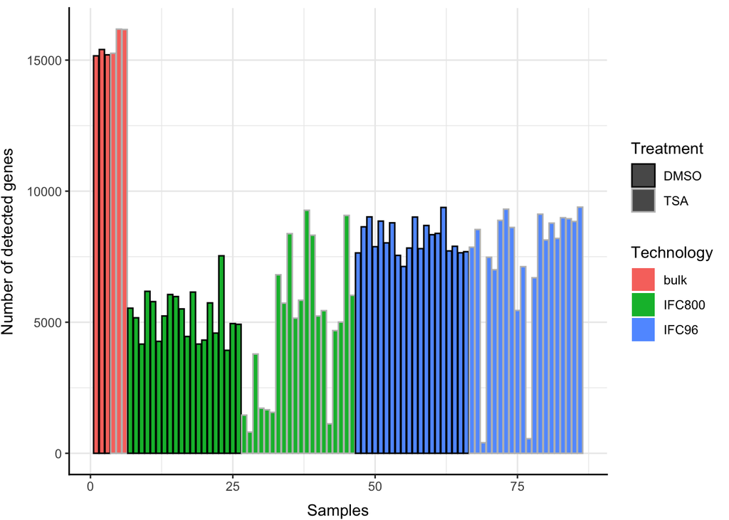

```r
ggplot(num_genes, aes(x = sample, y = num, fill = Technology, color = Treatment)) +
  geom_col() +
  scale_color_manual(values = c("black", "grey")) +
  labs(x = "Samples", y = "Number of detected genes") +
  theme_bw() +
  theme(
    axis.title.x = element_text(vjust = -1),
    axis.title.y = element_text(vjust = +3),
    panel.border = element_blank(),
    axis.line = element_line(color = "black", linewidth = 0.5, lineend = "square")
  )
```

### Total sum of counts per sample (serves as a proxy for the number of sequenced reads per sample)

```r
sum_counts <- cbind(anno, data.frame(colSums(x[2:nrow(x),])))
colnames(sum_counts)[ncol(sum_counts)] = "sum_counts"
head(sum_counts)
```

```
                      sample Treatment Technology sum_counts
bulk.DMSO-Pre-96IFC        1      DMSO       bulk   16469072
bulk.DMSO-Pre-800IFC       2      DMSO       bulk   22928016
bulk.DMSO-Post-800IFC      3      DMSO       bulk   16572277
bulk.TSA-Pre-96IFC         4       TSA       bulk   10899777
bulk.TSA-Pre-800IFC        5       TSA       bulk   21170430
bulk.TSA-Post-800IFC       6       TSA       bulk   21218842
```

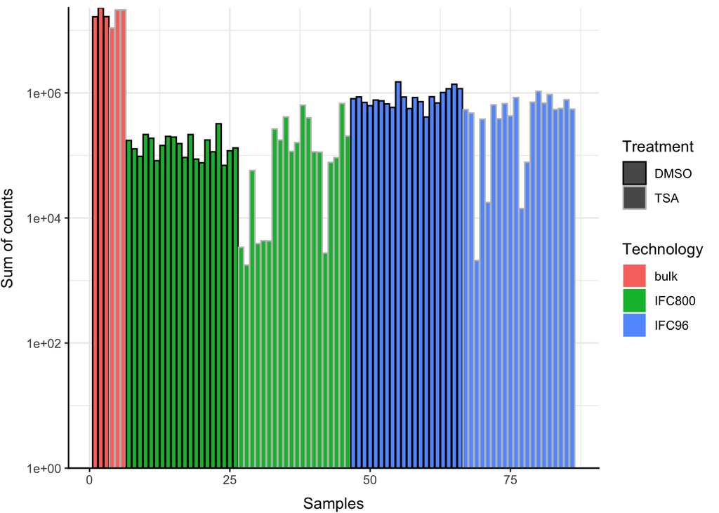

```r
ggplot(sum_counts, aes(x = sample, y = sum_counts, fill = Technology, color = Treatment)) +
  geom_col() +
  scale_y_continuous(
    expand = c(0, 0),
    trans = log10_trans()
  ) +
  scale_color_manual(values = c("black", "grey")) +
  labs(x = "Samples", y = "Sum of counts") +
  theme_bw() +
  theme(
    axis.title.x = element_text(vjust = -1),
    axis.title.y = element_text(vjust = +3),
    panel.border = element_blank(),
    axis.line = element_line(color = "black", linewidth = 0.5, lineend = "square")
  )
```

The total sum of counts for the bulk samples is 1-2 orders of magnitude greater than the IFC800 and IFC96 samples. The rest of the observations are quite similar to the number of detected genes per sample.

## Normalize the data

Scale the columns so that the total sum of all columns are identical.

```r
# norm_x scales the columns such that each column sum is equal to the maximum of the column sums of x
norm_x <- rbind(sample = 1:nrow(anno), sweep(x[2:nrow(x),]*max(sum_counts$sum_counts), 2, t(sum_counts$sum_counts), "/"))
```

## Transform the data to log-scale

Use the function `log1p` to transform the data to log-scale.

```r
# log_x transforms the normalized data to log-scale
log_x <- rbind(sample = 1:nrow(anno), log1p(x[2:nrow(x),]))
```

## Visualize the distribution of the expression values

Use violin plots and boxplots to visualize the distribution of the expression values. Aggregate the replicates in the same experimental group into one average sample, and plot the averaged sample. Color by experimental factors.

```r
# aggr_x contains expression data of all genes averaged over replicates for each sample
aggr_x <- data.frame(matrix(0, length(unique(anno$Treatment))*length(unique(anno$Technology)), nrow(log_x)-1))
colnames(aggr_x) = rownames(log_x[2:nrow(x),])
cats <- data.frame(Treatment = rep(rownames(repls), length(unique(anno$Technology))), Technology = rep(colnames(repls), each = length(unique(anno$Treatment))))
aggr_x <- cbind(cats, aggr_x)

for (i in 1:nrow(aggr_x)) {
aggr_x[i, 3:ncol(aggr_x)] <- rowMeans(log_x[2:nrow(log_x), (anno$Treatment == aggr_x$Treatment[i]) & (anno$Technology == aggr_x$Technology[i])])
}

# grp_x reshapes aggr_x for easy grouped violin plot
grp_x <- data.frame(matrix(0, (nrow(log_x)-1)*nrow(aggr_x), 4))
colnames(grp_x) = c(colnames(aggr_x)[1:2], "gene", "expr")
grp_x$Treatment <- rep(aggr_x$Treatment, nrow(log_x)-1)
grp_x$Technology <- rep(aggr_x$Technology, nrow(log_x)-1)
grp_x$gene <- rep(colnames(aggr_x)[3:ncol(aggr_x)], each = nrow(aggr_x))
grp_x$expr <- c(unname(as.matrix(aggr_x[, 3:ncol(aggr_x)])))
```

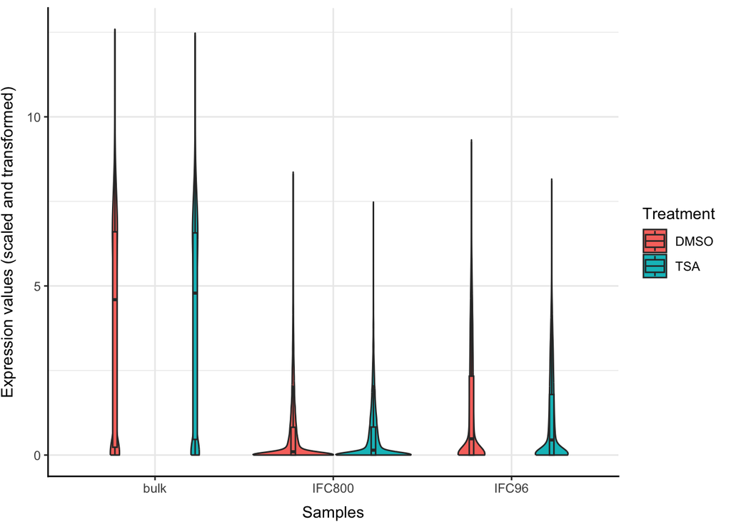

```r
ggplot(grp_x, aes(x = Technology, y = expr, fill = Treatment)) +
  geom_violin() +
  geom_boxplot(width = .05, outlier.colour = NA, position = position_dodge(width = 0.9)) +
  labs(x = "Samples", y = "Expression values (scaled and transformed)") +
  theme_bw() +
  theme(
    axis.title.x = element_text(vjust = -1),
    axis.title.y = element_text(vjust = +3),
    panel.border = element_blank(),
    axis.line = element_line(color = "black", linewidth = 0.5, lineend = "square")
  )
```

For all 3 technologies, the violin plots of the expression values look very similar for both treatments. For IFC800 samples, most expression values are very low, while IFC96 samples have slightly higher expression values. However, most strikingly, bulk samples have a considerably high fraction of higher expression values out of all expression values as compared to the IFC800 and IFC96 samples.

## Most variable genes

Identify the 500 most variable genes (with largest variance across samples) and continue working with those.

```r
# expr_vars contains variances in expression across samples for each gene
expr_vars <- as.data.frame(rowVars(as.matrix(log_x[2:nrow(log_x), ])))
colnames(expr_vars) = "expr_variance"

# top_vars sorts expr_vars in descending order and stores the 500 most variable genes
top_vars <- order(-as.matrix(expr_vars))[1:500]

#top_x contains expression data of 500 most variable genes
top_x <- cbind(anno, t(log_x[top_vars+1, ]))
```

## Sample correlations

Compute and visualize the sample-to-sample correlations.

```r
# correl stores Pearson correlation coefficient between each sample
correl <- matrix(0, nrow(top_x), nrow(top_x))
for (i in 1:nrow(top_x)) {
  for (j in 1:i) {
    correl[i,j] <- cor(as.numeric(top_x[i,4:ncol(top_x)]), as.numeric(top_x[j,4:ncol(top_x)]))
  }
}

# correl is converted to a symmetric dataframe for visualization
correl <- as.data.frame(correl + t(correl) - diag(diag(correl)))
colnames(correl) = 1:ncol(correl)
```

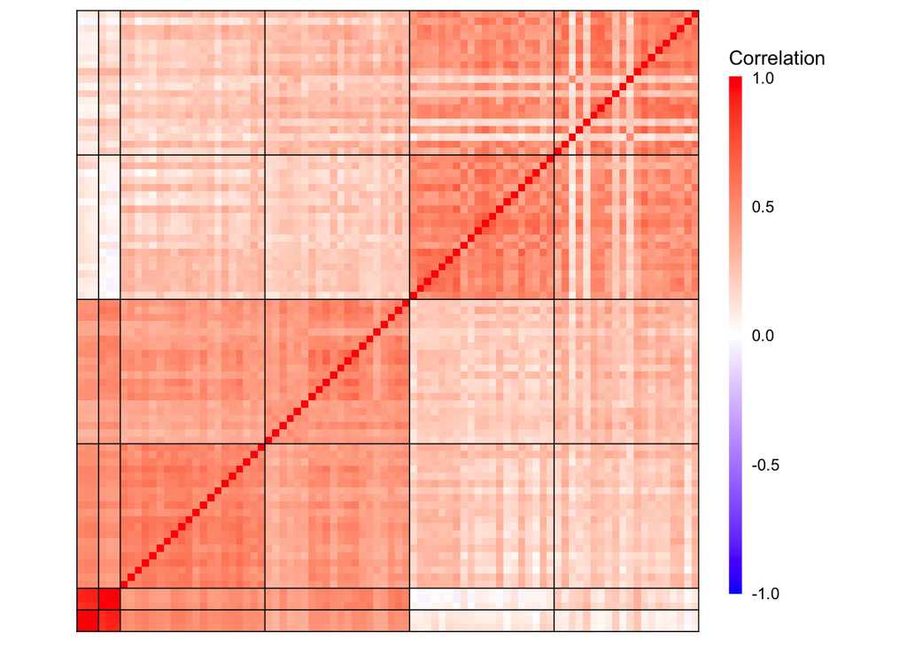

```r
melted_correl <- cbind(cond = rep(unname(paste0(top_x$Technology, '-', top_x$Treatment)), ncol(correl)), melt(cbind(sample = colnames(correl), correl), id.vars = "sample"))
ggplot(melted_correl, aes(x = factor(sample, level = rownames(correl)), y = variable, fill = value)) +
    geom_tile() +
    scale_fill_gradient2(low = "blue", high = "red", mid = "white",
    midpoint = 0, limit = c(-1,1), space = "Lab",
    name= "Correlation") +
    theme_bw() +
    theme(
      legend.text = element_text(size = 9),
      legend.title = element_text(size = 11),
      panel.grid.major = element_blank(),
      panel.border = element_blank(),
      panel.background = element_blank(),
      axis.ticks = element_blank(),
      axis.title.y = element_blank(),
      axis.title.x = element_blank(),
      axis.text.y = element_blank(),
      axis.text.x = element_blank()) +
    geom_vline(xintercept = c(0.5, cumsum(as.numeric(unlist(repls)))+0.5), colour="black", linewidth = 0.3) +
    geom_hline(yintercept = c(0.5, cumsum(as.numeric(unlist(repls)))+0.5), colour="black", linewidth = 0.3) +
    coord_fixed(ratio = 1) +
    guides(fill = guide_colourbar(barwidth = 0.5, barheight = 20, ticks = FALSE))
```

We observe that the expression profiles for the bulk samples (bottom, left) are highly correlated to each other. This is also true for the IFC800 (center, center) and IFC96 (top, right) samples within themselves, albeit with a smaller degree of correlation. The correlation between IFC800 and IFC96 samples is quite low throughout. Noticeably, we observe 4 samples within the TSA treated IFC96 samples which have poor correlation with all other samples.

## Clustering

Compute and visualize a hierarchical clustering of the samples, use the method `hclust`.

```r
# hc_x stores hierarchical clusters of samples calculated using Euclidean distance
hc_x <- hclust(dist(top_x[, 4:ncol(top_x)]))
hc_x[["labels"]] <- unname(paste0(top_x$Technology, '-', top_x$Treatment))
```

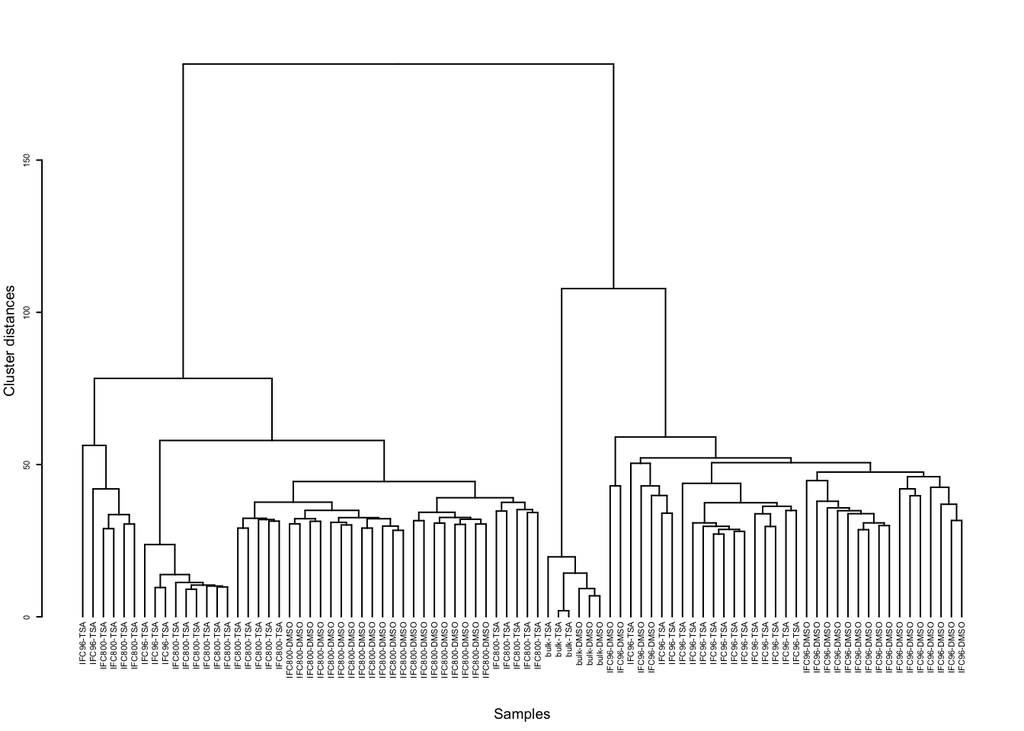

```r
par(mar = c(9, 4.1, 4.1, 2.1), cex = 0.35)
plot(as.dendrogram(hc_x))
mtext(side = 1, text = "Samples", line = 7, cex = 0.6)
mtext(side = 2, text = "Cluster distances", line = 2.5, cex = 0.6)
```

We observe that samples with similar treatments and technologies mostly cluster together, except a few TSA treated IFC96 samples (clustered with TSA treated IFC800 samples) which were identified from the sample-to-sample correlation values. We also notice that the bulk and the IFC96 samples cluster closer together than with the IFC800 samples.

## Heatmap

Use the package `pheatmap` to generate a heatmap of the expression data.

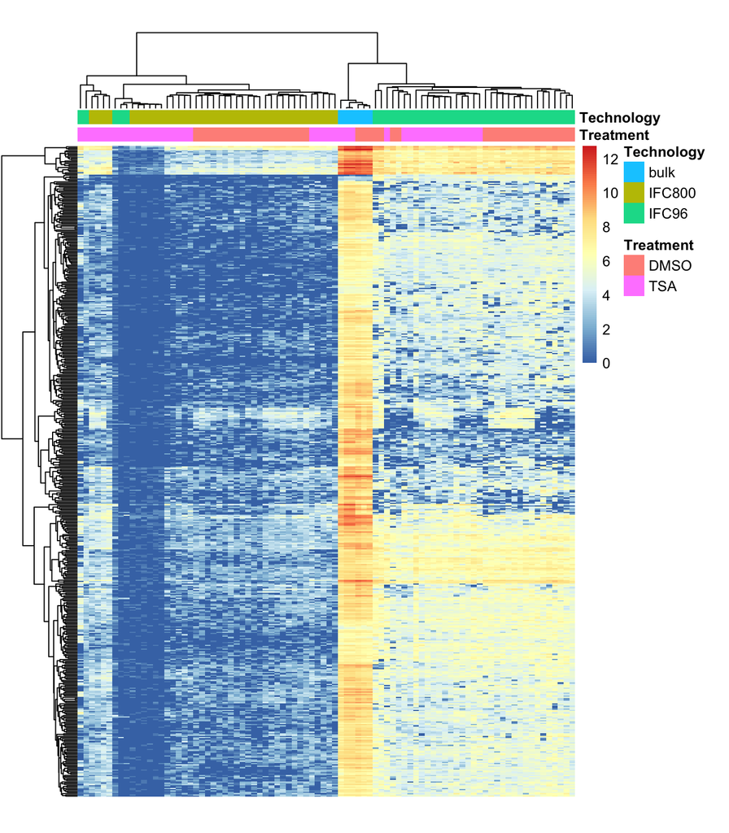

```r
# heatmap of normalized and transformed expression values of all genes per sample
# genes are also clustered hierarchically based on Euclidean distance between expression values
#| label: heatmap
#| fig-height: 20
pheatmap(t(as.matrix(top_x[, 4:ncol(top_x)])), cluster_rows = hclust(dist(t(top_x[, 4:ncol(top_x)]))), cluster_cols = hc_x,  show_rownames = FALSE, show_colnames = FALSE, annotation_col = top_x[,2:3], cellwidth = 4, cellheight = 0.9)
```

The most visually striking observation is that the bulk samples have higher expression values than the IFC800 and IFC96 samples, except for one small cluster of genes which has very low expression, and is expressed relatively more in the IFC96 samples. Expression values for the IFC800 samples are generally low, while those for IFC96 are mostly low to moderate, except for a few clusters of genes which are similar to the bulk samples. Noticeably, 9 of the samples (TSA treated IFC96 or IFC800) have very low expression values throughout. Coming to the effect of treatment, there are very few differences between DMSO and TSA treatment for all 3 technologies, apart from the above 9 TSA treated samples.

..